# Risk Factor Analysis

## Outcome Variable

**Outcome Variable:** ever_stunted

## Predictor Variables

**Intervention Variable:** enwast

**Adjustment Set:**

unadjusted

## Stratifying Variables

The analysis was stratified on these variable(s):

- agecat
- studyid
- country

## Data Summary

| agecat | studyid | country | enwast | ever_stunted | n_cell | n | outcome_variable |
| --- | --- | --- | --- | --- | --- | --- | --- |
| 0-24 months (no birth st.) | ki0047075b-MAL-ED | BANGLADESH | 0 | 0 | 81 | 217 | ever_stunted |
| 0-24 months (no birth st.) | ki0047075b-MAL-ED | BANGLADESH | 0 | 1 | 98 | 217 | ever_stunted |
| 0-24 months (no birth st.) | ki0047075b-MAL-ED | BANGLADESH | 1 | 0 | 22 | 217 | ever_stunted |
| 0-24 months (no birth st.) | ki0047075b-MAL-ED | BANGLADESH | 1 | 1 | 16 | 217 | ever_stunted |
| 0-24 months (no birth st.) | ki0047075b-MAL-ED | BRAZIL | 0 | 0 | 163 | 200 | ever_stunted |
| 0-24 months (no birth st.) | ki0047075b-MAL-ED | BRAZIL | 0 | 1 | 31 | 200 | ever_stunted |
| 0-24 months (no birth st.) | ki0047075b-MAL-ED | BRAZIL | 1 | 0 | 5 | 200 | ever_stunted |
| 0-24 months (no birth st.) | ki0047075b-MAL-ED | BRAZIL | 1 | 1 | 1 | 200 | ever_stunted |
| 0-24 months (no birth st.) | ki0047075b-MAL-ED | INDIA | 0 | 0 | 76 | 210 | ever_stunted |
| 0-24 months (no birth st.) | ki0047075b-MAL-ED | INDIA | 0 | 1 | 98 | 210 | ever_stunted |
| 0-24 months (no birth st.) | ki0047075b-MAL-ED | INDIA | 1 | 0 | 23 | 210 | ever_stunted |
| 0-24 months (no birth st.) | ki0047075b-MAL-ED | INDIA | 1 | 1 | 13 | 210 | ever_stunted |
| 0-24 months (no birth st.) | ki0047075b-MAL-ED | NEPAL | 0 | 0 | 139 | 211 | ever_stunted |
| 0-24 months (no birth st.) | ki0047075b-MAL-ED | NEPAL | 0 | 1 | 45 | 211 | ever_stunted |
| 0-24 months (no birth st.) | ki0047075b-MAL-ED | NEPAL | 1 | 0 | 17 | 211 | ever_stunted |
| 0-24 months (no birth st.) | ki0047075b-MAL-ED | NEPAL | 1 | 1 | 10 | 211 | ever_stunted |
| 0-24 months (no birth st.) | ki0047075b-MAL-ED | PERU | 0 | 0 | 113 | 266 | ever_stunted |
| 0-24 months (no birth st.) | ki0047075b-MAL-ED | PERU | 0 | 1 | 148 | 266 | ever_stunted |
| 0-24 months (no birth st.) | ki0047075b-MAL-ED | PERU | 1 | 0 | 2 | 266 | ever_stunted |
| 0-24 months (no birth st.) | ki0047075b-MAL-ED | PERU | 1 | 1 | 3 | 266 | ever_stunted |
| 0-24 months (no birth st.) | ki0047075b-MAL-ED | SOUTH AFRICA | 0 | 0 | 124 | 275 | ever_stunted |
| 0-24 months (no birth st.) | ki0047075b-MAL-ED | SOUTH AFRICA | 0 | 1 | 131 | 275 | ever_stunted |
| 0-24 months (no birth st.) | ki0047075b-MAL-ED | SOUTH AFRICA | 1 | 0 | 14 | 275 | ever_stunted |
| 0-24 months (no birth st.) | ki0047075b-MAL-ED | SOUTH AFRICA | 1 | 1 | 6 | 275 | ever_stunted |
| 0-24 months (no birth st.) | ki0047075b-MAL-ED | TANZANIA, UNITED REPUBLIC OF | 0 | 0 | 40 | 219 | ever_stunted |
| 0-24 months (no birth st.) | ki0047075b-MAL-ED | TANZANIA, UNITED REPUBLIC OF | 0 | 1 | 178 | 219 | ever_stunted |
| 0-24 months (no birth st.) | ki0047075b-MAL-ED | TANZANIA, UNITED REPUBLIC OF | 1 | 0 | 0 | 219 | ever_stunted |
| 0-24 months (no birth st.) | ki0047075b-MAL-ED | TANZANIA, UNITED REPUBLIC OF | 1 | 1 | 1 | 219 | ever_stunted |
| 0-24 months (no birth st.) | ki1000108-CMC-V-BCS-2002 | INDIA | 0 | 0 | 22 | 296 | ever_stunted |
| 0-24 months (no birth st.) | ki1000108-CMC-V-BCS-2002 | INDIA | 0 | 1 | 200 | 296 | ever_stunted |

[output cut: 338 more lines]

The following strata were considered:

- agecat: 0-24 months (no birth st.), studyid: ki0047075b-MAL-ED, country: BANGLADESH
- agecat: 0-24 months (no birth st.), studyid: ki0047075b-MAL-ED, country: BRAZIL
- agecat: 0-24 months (no birth st.), studyid: ki0047075b-MAL-ED, country: INDIA
- agecat: 0-24 months (no birth st.), studyid: ki0047075b-MAL-ED, country: NEPAL
- agecat: 0-24 months (no birth st.), studyid: ki0047075b-MAL-ED, country: PERU
- agecat: 0-24 months (no birth st.), studyid: ki0047075b-MAL-ED, country: SOUTH AFRICA
- agecat: 0-24 months (no birth st.), studyid: ki0047075b-MAL-ED, country: TANZANIA, UNITED REPUBLIC OF
- agecat: 0-24 months (no birth st.), studyid: ki1000108-CMC-V-BCS-2002, country: INDIA
- agecat: 0-24 months (no birth st.), studyid: ki1000108-IRC, country: INDIA
- agecat: 0-24 months (no birth st.), studyid: ki1000109-EE, country: PAKISTAN
- agecat: 0-24 months (no birth st.), studyid: ki1000109-ResPak, country: PAKISTAN
- agecat: 0-24 months (no birth st.), studyid: ki1000304b-SAS-CompFeed, country: INDIA
- agecat: 0-24 months (no birth st.), studyid: ki1000304b-SAS-FoodSuppl, country: INDIA
- agecat: 0-24 months (no birth st.), studyid: ki1017093-NIH-Birth, country: BANGLADESH
- agecat: 0-24 months (no birth st.), studyid: ki1017093b-PROVIDE, country: BANGLADESH
- agecat: 0-24 months (no birth st.), studyid: ki1017093c-NIH-Crypto, country: BANGLADESH
- agecat: 0-24 months (no birth st.), studyid: ki1066203-TanzaniaChild2, country: TANZANIA, UNITED REPUBLIC OF
- agecat: 0-24 months (no birth st.), studyid: ki1101329-Keneba, country: GAMBIA
- agecat: 0-24 months (no birth st.), studyid: ki1112895-Guatemala BSC, country: GUATEMALA
- agecat: 0-24 months (no birth st.), studyid: ki1112895-iLiNS-Zinc, country: BURKINA FASO
- agecat: 0-24 months (no birth st.), studyid: ki1113344-GMS-Nepal, country: NEPAL
- agecat: 0-24 months (no birth st.), studyid: ki1114097-CMIN, country: BANGLADESH
- agecat: 0-24 months (no birth st.), studyid: ki1114097-CONTENT, country: PERU
- agecat: 0-24 months (no birth st.), studyid: ki1119695-PROBIT, country: BELARUS
- agecat: 0-24 months (no birth st.), studyid: ki1126311-ZVITAMBO, country: ZIMBABWE
- agecat: 0-24 months (no birth st.), studyid: ki1135781-COHORTS, country: GUATEMALA
- agecat: 0-24 months (no birth st.), studyid: ki1135781-COHORTS, country: INDIA
- agecat: 0-24 months (no birth st.), studyid: ki1135781-COHORTS, country: PHILIPPINES
- agecat: 0-24 months (no birth st.), studyid: ki1148112-LCNI-5, country: MALAWI
- agecat: 0-24 months (no birth st.), studyid: kiGH5241-JiVitA-3, country: BANGLADESH
- agecat: 0-24 months (no birth st.), studyid: kiGH5241-JiVitA-4, country: BANGLADESH
- agecat: 0-6 months (no birth st.), studyid: ki0047075b-MAL-ED, country: BANGLADESH
- agecat: 0-6 months (no birth st.), studyid: ki0047075b-MAL-ED, country: BRAZIL
- agecat: 0-6 months (no birth st.), studyid: ki0047075b-MAL-ED, country: INDIA
- agecat: 0-6 months (no birth st.), studyid: ki0047075b-MAL-ED, country: NEPAL
- agecat: 0-6 months (no birth st.), studyid: ki0047075b-MAL-ED, country: PERU
- agecat: 0-6 months (no birth st.), studyid: ki0047075b-MAL-ED, country: SOUTH AFRICA
- agecat: 0-6 months (no birth st.), studyid: ki0047075b-MAL-ED, country: TANZANIA, UNITED REPUBLIC OF
- agecat: 0-6 months (no birth st.), studyid: ki1000108-CMC-V-BCS-2002, country: INDIA
- agecat: 0-6 months (no birth st.), studyid: ki1000108-IRC, country: INDIA
- agecat: 0-6 months (no birth st.), studyid: ki1000109-EE, country: PAKISTAN
- agecat: 0-6 months (no birth st.), studyid: ki1000109-ResPak, country: PAKISTAN
- agecat: 0-6 months (no birth st.), studyid: ki1000304b-SAS-CompFeed, country: INDIA
- agecat: 0-6 months (no birth st.), studyid: ki1000304b-SAS-FoodSuppl, country: INDIA
- agecat: 0-6 months (no birth st.), studyid: ki1017093-NIH-Birth, country: BANGLADESH
- agecat: 0-6 months (no birth st.), studyid: ki1017093b-PROVIDE, country: BANGLADESH
- agecat: 0-6 months (no birth st.), studyid: ki1017093c-NIH-Crypto, country: BANGLADESH
- agecat: 0-6 months (no birth st.), studyid: ki1066203-TanzaniaChild2, country: TANZANIA, UNITED REPUBLIC OF
- agecat: 0-6 months (no birth st.), studyid: ki1101329-Keneba, country: GAMBIA
- agecat: 0-6 months (no birth st.), studyid: ki1112895-Guatemala BSC, country: GUATEMALA
- agecat: 0-6 months (no birth st.), studyid: ki1113344-GMS-Nepal, country: NEPAL
- agecat: 0-6 months (no birth st.), studyid: ki1114097-CMIN, country: BANGLADESH
- agecat: 0-6 months (no birth st.), studyid: ki1114097-CONTENT, country: PERU
- agecat: 0-6 months (no birth st.), studyid: ki1119695-PROBIT, country: BELARUS
- agecat: 0-6 months (no birth st.), studyid: ki1126311-ZVITAMBO, country: ZIMBABWE
- agecat: 0-6 months (no birth st.), studyid: ki1135781-COHORTS, country: GUATEMALA
- agecat: 0-6 months (no birth st.), studyid: ki1135781-COHORTS, country: INDIA
- agecat: 0-6 months (no birth st.), studyid: ki1135781-COHORTS, country: PHILIPPINES
- agecat: 0-6 months (no birth st.), studyid: ki1148112-LCNI-5, country: MALAWI
- agecat: 0-6 months (no birth st.), studyid: kiGH5241-JiVitA-3, country: BANGLADESH
- agecat: 0-6 months (no birth st.), studyid: kiGH5241-JiVitA-4, country: BANGLADESH
- agecat: 6-24 months, studyid: ki0047075b-MAL-ED, country: BANGLADESH
- agecat: 6-24 months, studyid: ki0047075b-MAL-ED, country: BRAZIL
- agecat: 6-24 months, studyid: ki0047075b-MAL-ED, country: INDIA
- agecat: 6-24 months, studyid: ki0047075b-MAL-ED, country: NEPAL
- agecat: 6-24 months, studyid: ki0047075b-MAL-ED, country: PERU
- agecat: 6-24 months, studyid: ki0047075b-MAL-ED, country: SOUTH AFRICA
- agecat: 6-24 months, studyid: ki0047075b-MAL-ED, country: TANZANIA, UNITED REPUBLIC OF
- agecat: 6-24 months, studyid: ki1000108-CMC-V-BCS-2002, country: INDIA
- agecat: 6-24 months, studyid: ki1000108-IRC, country: INDIA
- agecat: 6-24 months, studyid: ki1000109-EE, country: PAKISTAN
- agecat: 6-24 months, studyid: ki1000109-ResPak, country: PAKISTAN
- agecat: 6-24 months, studyid: ki1000304b-SAS-CompFeed, country: INDIA
- agecat: 6-24 months, studyid: ki1000304b-SAS-FoodSuppl, country: INDIA
- agecat: 6-24 months, studyid: ki1017093-NIH-Birth, country: BANGLADESH
- agecat: 6-24 months, studyid: ki1017093b-PROVIDE, country: BANGLADESH
- agecat: 6-24 months, studyid: ki1017093c-NIH-Crypto, country: BANGLADESH
- agecat: 6-24 months, studyid: ki1066203-TanzaniaChild2, country: TANZANIA, UNITED REPUBLIC OF
- agecat: 6-24 months, studyid: ki1101329-Keneba, country: GAMBIA
- agecat: 6-24 months, studyid: ki1112895-Guatemala BSC, country: GUATEMALA
- agecat: 6-24 months, studyid: ki1112895-iLiNS-Zinc, country: BURKINA FASO
- agecat: 6-24 months, studyid: ki1113344-GMS-Nepal, country: NEPAL
- agecat: 6-24 months, studyid: ki1114097-CMIN, country: BANGLADESH
- agecat: 6-24 months, studyid: ki1114097-CONTENT, country: PERU
- agecat: 6-24 months, studyid: ki1119695-PROBIT, country: BELARUS
- agecat: 6-24 months, studyid: ki1126311-ZVITAMBO, country: ZIMBABWE
- agecat: 6-24 months, studyid: ki1135781-COHORTS, country: GUATEMALA
- agecat: 6-24 months, studyid: ki1135781-COHORTS, country: INDIA
- agecat: 6-24 months, studyid: ki1135781-COHORTS, country: PHILIPPINES
- agecat: 6-24 months, studyid: ki1148112-LCNI-5, country: MALAWI
- agecat: 6-24 months, studyid: kiGH5241-JiVitA-3, country: BANGLADESH
- agecat: 6-24 months, studyid: kiGH5241-JiVitA-4, country: BANGLADESH

### Dropped Strata

Some strata were dropped due to rare outcomes:

- agecat: 0-24 months (no birth st.), studyid: ki0047075b-MAL-ED, country: BRAZIL
- agecat: 0-24 months (no birth st.), studyid: ki0047075b-MAL-ED, country: PERU
- agecat: 0-24 months (no birth st.), studyid: ki0047075b-MAL-ED, country: TANZANIA, UNITED REPUBLIC OF
- agecat: 0-24 months (no birth st.), studyid: ki1000109-EE, country: PAKISTAN
- agecat: 0-24 months (no birth st.), studyid: ki1112895-Guatemala BSC, country: GUATEMALA
- agecat: 0-24 months (no birth st.), studyid: ki1114097-CONTENT, country: PERU
- agecat: 0-24 months (no birth st.), studyid: ki1148112-LCNI-5, country: MALAWI
- agecat: 0-6 months (no birth st.), studyid: ki0047075b-MAL-ED, country: BRAZIL
- agecat: 0-6 months (no birth st.), studyid: ki0047075b-MAL-ED, country: NEPAL
- agecat: 0-6 months (no birth st.), studyid: ki0047075b-MAL-ED, country: PERU
- agecat: 0-6 months (no birth st.), studyid: ki0047075b-MAL-ED, country: SOUTH AFRICA
- agecat: 0-6 months (no birth st.), studyid: ki0047075b-MAL-ED, country: TANZANIA, UNITED REPUBLIC OF
- agecat: 0-6 months (no birth st.), studyid: ki1000304b-SAS-FoodSuppl, country: INDIA
- agecat: 0-6 months (no birth st.), studyid: ki1112895-Guatemala BSC, country: GUATEMALA
- agecat: 0-6 months (no birth st.), studyid: ki1114097-CONTENT, country: PERU
- agecat: 0-6 months (no birth st.), studyid: ki1148112-LCNI-5, country: MALAWI
- agecat: 6-24 months, studyid: ki0047075b-MAL-ED, country: BRAZIL
- agecat: 6-24 months, studyid: ki0047075b-MAL-ED, country: PERU
- agecat: 6-24 months, studyid: ki0047075b-MAL-ED, country: SOUTH AFRICA
- agecat: 6-24 months, studyid: ki0047075b-MAL-ED, country: TANZANIA, UNITED REPUBLIC OF
- agecat: 6-24 months, studyid: ki1000109-EE, country: PAKISTAN
- agecat: 6-24 months, studyid: ki1000109-ResPak, country: PAKISTAN
- agecat: 6-24 months, studyid: ki1112895-Guatemala BSC, country: GUATEMALA
- agecat: 6-24 months, studyid: ki1114097-CMIN, country: BANGLADESH
- agecat: 6-24 months, studyid: ki1114097-CONTENT, country: PERU
- agecat: 6-24 months, studyid: ki1148112-LCNI-5, country: MALAWI

## Methods Detail

We’re interested in the causal parameters $E[Y_a]$ for all values of $a \in \mathcal{A}$. These parameters represent the mean outcome if, possibly contrary to fact, we intervened to set all units to have $A=a$. Under the randomization and positivity assumptions, these are identified by the statistical parameters $\psi_a=E_W[E_{Y|A,W}(Y|A=a,W)]$. In addition, we’re interested in the mean of $Y$, $E[Y]$ under no intervention (the observed mean). We will estimate these parameters by using SuperLearner to fit the relevant likelihood factors – $E_{Y|A,W}(Y|A=a,W)$ and $p(A=a|W)$, and then updating our likelihood fit using a joint TMLE.

For unadjusted analyses ($W=\{\}$), initial likelihoods were estimated using Lrnr_glm to estimate the simple $E(Y|A)$ and Lrnr_mean to estimate $p(A)$. For adjusted analyses, a small library containing Lrnr_glmnet, Lrnr_xgboost, and Lrnr_mean was used.

Having estimated these parameters, we will then use the delta method to estimate relative risks and attributable risks relative to a prespecified baseline level of $A$.

# Results Detail

## Results Plots

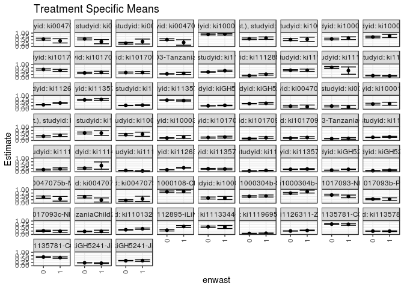

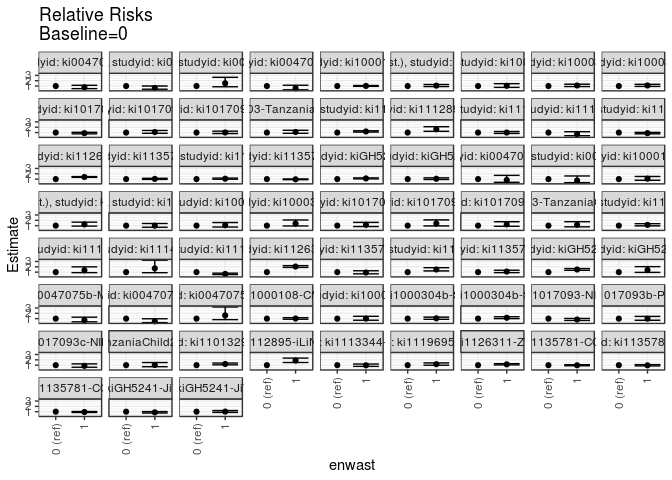

[figure not shown]

[figure not shown]

## Results Table

### Parameter: TSM

| agecat | studyid | country | intervention_level | baseline_level | estimate | ci_lower | ci_upper |
| --- | --- | --- | --- | --- | --- | --- | --- |
| 0-24 months (no birth st.) | ki0047075b-MAL-ED | BANGLADESH | 0 | NA | 0.5474860 | 0.4744012 | 0.6205708 |
| 0-24 months (no birth st.) | ki0047075b-MAL-ED | BANGLADESH | 1 | NA | 0.4210526 | 0.2637098 | 0.5783955 |
| 0-24 months (no birth st.) | ki0047075b-MAL-ED | INDIA | 0 | NA | 0.5632184 | 0.4893463 | 0.6370905 |
| 0-24 months (no birth st.) | ki0047075b-MAL-ED | INDIA | 1 | NA | 0.3611111 | 0.2038337 | 0.5183886 |
| 0-24 months (no birth st.) | ki0047075b-MAL-ED | NEPAL | 0 | NA | 0.2445652 | 0.1823113 | 0.3068191 |
| 0-24 months (no birth st.) | ki0047075b-MAL-ED | NEPAL | 1 | NA | 0.3703704 | 0.1877881 | 0.5529526 |
| 0-24 months (no birth st.) | ki0047075b-MAL-ED | SOUTH AFRICA | 0 | NA | 0.5137255 | 0.4522679 | 0.5751831 |
| 0-24 months (no birth st.) | ki0047075b-MAL-ED | SOUTH AFRICA | 1 | NA | 0.3000000 | 0.0987973 | 0.5012027 |
| 0-24 months (no birth st.) | ki1000108-CMC-V-BCS-2002 | INDIA | 0 | NA | 0.9009009 | 0.8615296 | 0.9402722 |
| 0-24 months (no birth st.) | ki1000108-CMC-V-BCS-2002 | INDIA | 1 | NA | 0.9189189 | 0.8566222 | 0.9812157 |
| 0-24 months (no birth st.) | ki1000108-IRC | INDIA | 0 | NA | 0.5761317 | 0.5139109 | 0.6383525 |
| 0-24 months (no birth st.) | ki1000108-IRC | INDIA | 1 | NA | 0.6216216 | 0.5312718 | 0.7119714 |
| 0-24 months (no birth st.) | ki1000109-ResPak | PAKISTAN | 0 | NA | 0.5153374 | 0.4384248 | 0.5922500 |
| 0-24 months (no birth st.) | ki1000109-ResPak | PAKISTAN | 1 | NA | 0.5384615 | 0.3816151 | 0.6953080 |
| 0-24 months (no birth st.) | ki1000304b-SAS-CompFeed | INDIA | 0 | NA | 0.5596708 | 0.4959887 | 0.6233529 |
| 0-24 months (no birth st.) | ki1000304b-SAS-CompFeed | INDIA | 1 | NA | 0.6186441 | 0.5158039 | 0.7214843 |
| 0-24 months (no birth st.) | ki1000304b-SAS-FoodSuppl | INDIA | 0 | NA | 0.7061611 | 0.6445783 | 0.7677440 |
| 0-24 months (no birth st.) | ki1000304b-SAS-FoodSuppl | INDIA | 1 | NA | 0.7826087 | 0.6631799 | 0.9020375 |
| 0-24 months (no birth st.) | ki1017093-NIH-Birth | BANGLADESH | 0 | NA | 0.6213333 | 0.5721935 | 0.6704731 |
| 0-24 months (no birth st.) | ki1017093-NIH-Birth | BANGLADESH | 1 | NA | 0.5548387 | 0.4765256 | 0.6331518 |
| 0-24 months (no birth st.) | ki1017093b-PROVIDE | BANGLADESH | 0 | NA | 0.3685259 | 0.3262930 | 0.4107588 |
| 0-24 months (no birth st.) | ki1017093b-PROVIDE | BANGLADESH | 1 | NA | 0.4045802 | 0.3204659 | 0.4886944 |
| 0-24 months (no birth st.) | ki1017093c-NIH-Crypto | BANGLADESH | 0 | NA | 0.3917526 | 0.3482759 | 0.4352292 |
| 0-24 months (no birth st.) | ki1017093c-NIH-Crypto | BANGLADESH | 1 | NA | 0.3988095 | 0.3247101 | 0.4729090 |
| 0-24 months (no birth st.) | ki1066203-TanzaniaChild2 | TANZANIA, UNITED REPUBLIC OF | 0 | NA | 0.2965616 | 0.2769944 | 0.3161288 |
| 0-24 months (no birth st.) | ki1066203-TanzaniaChild2 | TANZANIA, UNITED REPUBLIC OF | 1 | NA | 0.3283582 | 0.2488273 | 0.4078891 |
| 0-24 months (no birth st.) | ki1101329-Keneba | GAMBIA | 0 | NA | 0.4367871 | 0.4155898 | 0.4579844 |
| 0-24 months (no birth st.) | ki1101329-Keneba | GAMBIA | 1 | NA | 0.5277778 | 0.4825393 | 0.5730163 |
| 0-24 months (no birth st.) | ki1112895-iLiNS-Zinc | BURKINA FASO | 0 | NA | 0.1657682 | 0.1394465 | 0.1920899 |
| 0-24 months (no birth st.) | ki1112895-iLiNS-Zinc | BURKINA FASO | 1 | NA | 0.2671010 | 0.2047589 | 0.3294430 |

[output cut: 102 more lines]

### Parameter: E(Y)

| agecat | studyid | country | intervention_level | baseline_level | estimate | ci_lower | ci_upper |
| --- | --- | --- | --- | --- | --- | --- | --- |
| 0-24 months (no birth st.) | ki0047075b-MAL-ED | BANGLADESH | NA | NA | 0.5253456 | 0.4587520 | 0.5919392 |
| 0-24 months (no birth st.) | ki0047075b-MAL-ED | INDIA | NA | NA | 0.5285714 | 0.4608954 | 0.5962474 |
| 0-24 months (no birth st.) | ki0047075b-MAL-ED | NEPAL | NA | NA | 0.2606635 | 0.2012891 | 0.3200380 |
| 0-24 months (no birth st.) | ki0047075b-MAL-ED | SOUTH AFRICA | NA | NA | 0.4981818 | 0.4389793 | 0.5573843 |
| 0-24 months (no birth st.) | ki1000108-CMC-V-BCS-2002 | INDIA | NA | NA | 0.9054054 | 0.8720096 | 0.9388012 |
| 0-24 months (no birth st.) | ki1000108-IRC | INDIA | NA | NA | 0.5903955 | 0.5390958 | 0.6416952 |
| 0-24 months (no birth st.) | ki1000109-ResPak | PAKISTAN | NA | NA | 0.5198020 | 0.4507336 | 0.5888704 |
| 0-24 months (no birth st.) | ki1000304b-SAS-CompFeed | INDIA | NA | NA | 0.5660550 | 0.5086421 | 0.6234680 |
| 0-24 months (no birth st.) | ki1000304b-SAS-FoodSuppl | INDIA | NA | NA | 0.7198444 | 0.6648337 | 0.7748550 |
| 0-24 months (no birth st.) | ki1017093-NIH-Birth | BANGLADESH | NA | NA | 0.6018868 | 0.5601729 | 0.6436007 |
| 0-24 months (no birth st.) | ki1017093b-PROVIDE | BANGLADESH | NA | NA | 0.3759874 | 0.3382238 | 0.4137509 |
| 0-24 months (no birth st.) | ki1017093c-NIH-Crypto | BANGLADESH | NA | NA | 0.3935681 | 0.3560687 | 0.4310676 |
| 0-24 months (no birth st.) | ki1066203-TanzaniaChild2 | TANZANIA, UNITED REPUBLIC OF | NA | NA | 0.2984740 | 0.2794692 | 0.3174788 |
| 0-24 months (no birth st.) | ki1101329-Keneba | GAMBIA | NA | NA | 0.4533437 | 0.4341009 | 0.4725865 |
| 0-24 months (no birth st.) | ki1112895-iLiNS-Zinc | BURKINA FASO | NA | NA | 0.1780497 | 0.1518612 | 0.2042383 |
| 0-24 months (no birth st.) | ki1113344-GMS-Nepal | NEPAL | NA | NA | 0.5634783 | 0.5229056 | 0.6040509 |
| 0-24 months (no birth st.) | ki1114097-CMIN | BANGLADESH | NA | NA | 0.7559524 | 0.6908084 | 0.8210964 |
| 0-24 months (no birth st.) | ki1119695-PROBIT | BELARUS | NA | NA | 0.1597778 | 0.1408215 | 0.1787342 |
| 0-24 months (no birth st.) | ki1126311-ZVITAMBO | ZIMBABWE | NA | NA | 0.3491124 | 0.3407575 | 0.3574673 |
| 0-24 months (no birth st.) | ki1135781-COHORTS | GUATEMALA | NA | NA | 0.6972194 | 0.6683052 | 0.7261335 |
| 0-24 months (no birth st.) | ki1135781-COHORTS | INDIA | NA | NA | 0.2815773 | 0.2706357 | 0.2925189 |
| 0-24 months (no birth st.) | ki1135781-COHORTS | PHILIPPINES | NA | NA | 0.6647828 | 0.6473904 | 0.6821751 |
| 0-24 months (no birth st.) | kiGH5241-JiVitA-3 | BANGLADESH | NA | NA | 0.2522591 | 0.2445215 | 0.2599967 |
| 0-24 months (no birth st.) | kiGH5241-JiVitA-4 | BANGLADESH | NA | NA | 0.4137487 | 0.3955533 | 0.4319441 |
| 0-6 months (no birth st.) | ki0047075b-MAL-ED | BANGLADESH | NA | NA | 0.2165899 | 0.1616567 | 0.2715231 |
| 0-6 months (no birth st.) | ki0047075b-MAL-ED | INDIA | NA | NA | 0.2190476 | 0.1629743 | 0.2751210 |
| 0-6 months (no birth st.) | ki1000108-CMC-V-BCS-2002 | INDIA | NA | NA | 0.3835616 | 0.3276935 | 0.4394298 |
| 0-6 months (no birth st.) | ki1000108-IRC | INDIA | NA | NA | 0.3389831 | 0.2896025 | 0.3883636 |
| 0-6 months (no birth st.) | ki1000109-EE | PAKISTAN | NA | NA | 0.5539906 | 0.4870787 | 0.6209025 |
| 0-6 months (no birth st.) | ki1000109-ResPak | PAKISTAN | NA | NA | 0.4356436 | 0.3670959 | 0.5041912 |
| 0-6 months (no birth st.) | ki1000304b-SAS-CompFeed | INDIA | NA | NA | 0.1928375 | 0.1691727 | 0.2165022 |
| 0-6 months (no birth st.) | ki1017093-NIH-Birth | BANGLADESH | NA | NA | 0.2283019 | 0.1925336 | 0.2640702 |
| 0-6 months (no birth st.) | ki1017093b-PROVIDE | BANGLADESH | NA | NA | 0.1595577 | 0.1310079 | 0.1881074 |
| 0-6 months (no birth st.) | ki1017093c-NIH-Crypto | BANGLADESH | NA | NA | 0.1898928 | 0.1597870 | 0.2199986 |
| 0-6 months (no birth st.) | ki1066203-TanzaniaChild2 | TANZANIA, UNITED REPUBLIC OF | NA | NA | 0.1368941 | 0.1226179 | 0.1511703 |
| 0-6 months (no birth st.) | ki1101329-Keneba | GAMBIA | NA | NA | 0.2419720 | 0.2241162 | 0.2598277 |
| 0-6 months (no birth st.) | ki1113344-GMS-Nepal | NEPAL | NA | NA | 0.1739130 | 0.1429052 | 0.2049209 |
| 0-6 months (no birth st.) | ki1114097-CMIN | BANGLADESH | NA | NA | 0.2857143 | 0.2171983 | 0.3542303 |
| 0-6 months (no birth st.) | ki1119695-PROBIT | BELARUS | NA | NA | 0.0912784 | 0.0781588 | 0.1043979 |
| 0-6 months (no birth st.) | ki1126311-ZVITAMBO | ZIMBABWE | NA | NA | 0.1720551 | 0.1654372 | 0.1786729 |
| 0-6 months (no birth st.) | ki1135781-COHORTS | GUATEMALA | NA | NA | 0.2195677 | 0.1921865 | 0.2469489 |
| 0-6 months (no birth st.) | ki1135781-COHORTS | INDIA | NA | NA | 0.0732095 | 0.0667753 | 0.0796436 |
| 0-6 months (no birth st.) | ki1135781-COHORTS | PHILIPPINES | NA | NA | 0.1889792 | 0.1745554 | 0.2034029 |
| 0-6 months (no birth st.) | kiGH5241-JiVitA-3 | BANGLADESH | NA | NA | 0.1303067 | 0.1247240 | 0.1358893 |
| 0-6 months (no birth st.) | kiGH5241-JiVitA-4 | BANGLADESH | NA | NA | 0.0855893 | 0.0742297 | 0.0969489 |
| 6-24 months | ki0047075b-MAL-ED | BANGLADESH | NA | NA | 0.4240506 | 0.3467471 | 0.5013542 |
| 6-24 months | ki0047075b-MAL-ED | INDIA | NA | NA | 0.4220779 | 0.3438191 | 0.5003367 |
| 6-24 months | ki0047075b-MAL-ED | NEPAL | NA | NA | 0.2113402 | 0.1537425 | 0.2689379 |
| 6-24 months | ki1000108-CMC-V-BCS-2002 | INDIA | NA | NA | 0.8478261 | 0.7957850 | 0.8998671 |
| 6-24 months | ki1000108-IRC | INDIA | NA | NA | 0.3803419 | 0.3180067 | 0.4426771 |
| 6-24 months | ki1000304b-SAS-CompFeed | INDIA | NA | NA | 0.5030750 | 0.4588491 | 0.5473009 |
| 6-24 months | ki1000304b-SAS-FoodSuppl | INDIA | NA | NA | 0.7572016 | 0.7031798 | 0.8112234 |
| 6-24 months | ki1017093-NIH-Birth | BANGLADESH | NA | NA | 0.5739130 | 0.5216565 | 0.6261696 |
| 6-24 months | ki1017093b-PROVIDE | BANGLADESH | NA | NA | 0.3004386 | 0.2583143 | 0.3425629 |
| 6-24 months | ki1017093c-NIH-Crypto | BANGLADESH | NA | NA | 0.2628458 | 0.2244546 | 0.3012371 |
| 6-24 months | ki1066203-TanzaniaChild2 | TANZANIA, UNITED REPUBLIC OF | NA | NA | 0.2255639 | 0.2050525 | 0.2460753 |
| 6-24 months | ki1101329-Keneba | GAMBIA | NA | NA | 0.3601801 | 0.3391307 | 0.3812295 |
| 6-24 months | ki1112895-iLiNS-Zinc | BURKINA FASO | NA | NA | 0.3623277 | 0.3130786 | 0.4115769 |
| 6-24 months | ki1113344-GMS-Nepal | NEPAL | NA | NA | 0.5656566 | 0.5167753 | 0.6145378 |
| 6-24 months | ki1119695-PROBIT | BELARUS | NA | NA | 0.0768510 | 0.0628857 | 0.0908164 |
| 6-24 months | ki1126311-ZVITAMBO | ZIMBABWE | NA | NA | 0.2634638 | 0.2540597 | 0.2728679 |
| 6-24 months | ki1135781-COHORTS | GUATEMALA | NA | NA | 0.7684332 | 0.7403543 | 0.7965121 |
| 6-24 months | ki1135781-COHORTS | INDIA | NA | NA | 0.2473250 | 0.2361242 | 0.2585258 |
| 6-24 months | ki1135781-COHORTS | PHILIPPINES | NA | NA | 0.6435738 | 0.6230503 | 0.6640973 |
| 6-24 months | kiGH5241-JiVitA-3 | BANGLADESH | NA | NA | 0.2157031 | 0.2063258 | 0.2250804 |
| 6-24 months | kiGH5241-JiVitA-4 | BANGLADESH | NA | NA | 0.3776070 | 0.3590122 | 0.3962019 |

### Parameter: RR

| agecat | studyid | country | intervention_level | baseline_level | estimate | ci_lower | ci_upper |
| --- | --- | --- | --- | --- | --- | --- | --- |
| 0-24 months (no birth st.) | ki0047075b-MAL-ED | BANGLADESH | 0 | 0 | 1.0000000 | 1.0000000 | 1.0000000 |
| 0-24 months (no birth st.) | ki0047075b-MAL-ED | BANGLADESH | 1 | 0 | 0.7690655 | 0.5171636 | 1.1436648 |
| 0-24 months (no birth st.) | ki0047075b-MAL-ED | INDIA | 0 | 0 | 1.0000000 | 1.0000000 | 1.0000000 |
| 0-24 months (no birth st.) | ki0047075b-MAL-ED | INDIA | 1 | 0 | 0.6411565 | 0.4068381 | 1.0104306 |
| 0-24 months (no birth st.) | ki0047075b-MAL-ED | NEPAL | 0 | 0 | 1.0000000 | 1.0000000 | 1.0000000 |
| 0-24 months (no birth st.) | ki0047075b-MAL-ED | NEPAL | 1 | 0 | 1.5144033 | 0.8695401 | 2.6375062 |
| 0-24 months (no birth st.) | ki0047075b-MAL-ED | SOUTH AFRICA | 0 | 0 | 1.0000000 | 1.0000000 | 1.0000000 |
| 0-24 months (no birth st.) | ki0047075b-MAL-ED | SOUTH AFRICA | 1 | 0 | 0.5839695 | 0.2954758 | 1.1541396 |
| 0-24 months (no birth st.) | ki1000108-CMC-V-BCS-2002 | INDIA | 0 | 0 | 1.0000000 | 1.0000000 | 1.0000000 |
| 0-24 months (no birth st.) | ki1000108-CMC-V-BCS-2002 | INDIA | 1 | 0 | 1.0200000 | 0.9409586 | 1.1056810 |
| 0-24 months (no birth st.) | ki1000108-IRC | INDIA | 0 | 0 | 1.0000000 | 1.0000000 | 1.0000000 |
| 0-24 months (no birth st.) | ki1000108-IRC | INDIA | 1 | 0 | 1.0789575 | 0.9002514 | 1.2931381 |
| 0-24 months (no birth st.) | ki1000109-ResPak | PAKISTAN | 0 | 0 | 1.0000000 | 1.0000000 | 1.0000000 |
| 0-24 months (no birth st.) | ki1000109-ResPak | PAKISTAN | 1 | 0 | 1.0448718 | 0.7532174 | 1.4494581 |
| 0-24 months (no birth st.) | ki1000304b-SAS-CompFeed | INDIA | 0 | 0 | 1.0000000 | 1.0000000 | 1.0000000 |
| 0-24 months (no birth st.) | ki1000304b-SAS-CompFeed | INDIA | 1 | 0 | 1.1053714 | 0.9056531 | 1.3491323 |
| 0-24 months (no birth st.) | ki1000304b-SAS-FoodSuppl | INDIA | 0 | 0 | 1.0000000 | 1.0000000 | 1.0000000 |
| 0-24 months (no birth st.) | ki1000304b-SAS-FoodSuppl | INDIA | 1 | 0 | 1.1082580 | 0.9296242 | 1.3212174 |
| 0-24 months (no birth st.) | ki1017093-NIH-Birth | BANGLADESH | 0 | 0 | 1.0000000 | 1.0000000 | 1.0000000 |
| 0-24 months (no birth st.) | ki1017093-NIH-Birth | BANGLADESH | 1 | 0 | 0.8929808 | 0.7595849 | 1.0498032 |
| 0-24 months (no birth st.) | ki1017093b-PROVIDE | BANGLADESH | 0 | 0 | 1.0000000 | 1.0000000 | 1.0000000 |
| 0-24 months (no birth st.) | ki1017093b-PROVIDE | BANGLADESH | 1 | 0 | 1.0978337 | 0.8658369 | 1.3919929 |
| 0-24 months (no birth st.) | ki1017093c-NIH-Crypto | BANGLADESH | 0 | 0 | 1.0000000 | 1.0000000 | 1.0000000 |
| 0-24 months (no birth st.) | ki1017093c-NIH-Crypto | BANGLADESH | 1 | 0 | 1.0180138 | 0.8199030 | 1.2639935 |
| 0-24 months (no birth st.) | ki1066203-TanzaniaChild2 | TANZANIA, UNITED REPUBLIC OF | 0 | 0 | 1.0000000 | 1.0000000 | 1.0000000 |
| 0-24 months (no birth st.) | ki1066203-TanzaniaChild2 | TANZANIA, UNITED REPUBLIC OF | 1 | 0 | 1.1072175 | 0.8614109 | 1.4231660 |
| 0-24 months (no birth st.) | ki1101329-Keneba | GAMBIA | 0 | 0 | 1.0000000 | 1.0000000 | 1.0000000 |
| 0-24 months (no birth st.) | ki1101329-Keneba | GAMBIA | 1 | 0 | 1.2083182 | 1.0949728 | 1.3333965 |
| 0-24 months (no birth st.) | ki1112895-iLiNS-Zinc | BURKINA FASO | 0 | 0 | 1.0000000 | 1.0000000 | 1.0000000 |
| 0-24 months (no birth st.) | ki1112895-iLiNS-Zinc | BURKINA FASO | 1 | 0 | 1.6112921 | 1.2367998 | 2.0991773 |

[output cut: 102 more lines]

### Parameter: PAR

| agecat | studyid | country | intervention_level | baseline_level | estimate | ci_lower | ci_upper |
| --- | --- | --- | --- | --- | --- | --- | --- |
| 0-24 months (no birth st.) | ki0047075b-MAL-ED | BANGLADESH | 0 | NA | -0.0221404 | -0.0531893 | 0.0089085 |
| 0-24 months (no birth st.) | ki0047075b-MAL-ED | INDIA | 0 | NA | -0.0346470 | -0.0661740 | -0.0031199 |
| 0-24 months (no birth st.) | ki0047075b-MAL-ED | NEPAL | 0 | NA | 0.0160983 | -0.0092320 | 0.0414286 |
| 0-24 months (no birth st.) | ki0047075b-MAL-ED | SOUTH AFRICA | 0 | NA | -0.0155437 | -0.0321956 | 0.0011083 |
| 0-24 months (no birth st.) | ki1000108-CMC-V-BCS-2002 | INDIA | 0 | NA | 0.0045045 | -0.0139408 | 0.0229498 |
| 0-24 months (no birth st.) | ki1000108-IRC | INDIA | 0 | NA | 0.0142638 | -0.0202046 | 0.0487322 |
| 0-24 months (no birth st.) | ki1000109-ResPak | PAKISTAN | 0 | NA | 0.0044646 | -0.0292862 | 0.0382153 |
| 0-24 months (no birth st.) | ki1000304b-SAS-CompFeed | INDIA | 0 | NA | 0.0063843 | -0.0074146 | 0.0201832 |
| 0-24 months (no birth st.) | ki1000304b-SAS-FoodSuppl | INDIA | 0 | NA | 0.0136832 | -0.0106341 | 0.0380006 |
| 0-24 months (no birth st.) | ki1017093-NIH-Birth | BANGLADESH | 0 | NA | -0.0194465 | -0.0466074 | 0.0077143 |
| 0-24 months (no birth st.) | ki1017093b-PROVIDE | BANGLADESH | 0 | NA | 0.0074615 | -0.0120503 | 0.0269732 |
| 0-24 months (no birth st.) | ki1017093c-NIH-Crypto | BANGLADESH | 0 | NA | 0.0018156 | -0.0202887 | 0.0239199 |
| 0-24 months (no birth st.) | ki1066203-TanzaniaChild2 | TANZANIA, UNITED REPUBLIC OF | 0 | NA | 0.0019124 | -0.0030236 | 0.0068483 |
| 0-24 months (no birth st.) | ki1101329-Keneba | GAMBIA | 0 | NA | 0.0165566 | 0.0073655 | 0.0257478 |
| 0-24 months (no birth st.) | ki1112895-iLiNS-Zinc | BURKINA FASO | 0 | NA | 0.0122815 | 0.0047769 | 0.0197862 |
| 0-24 months (no birth st.) | ki1113344-GMS-Nepal | NEPAL | 0 | NA | 0.0002854 | -0.0209849 | 0.0215556 |
| 0-24 months (no birth st.) | ki1114097-CMIN | BANGLADESH | 0 | NA | -0.0182412 | -0.0418995 | 0.0054172 |
| 0-24 months (no birth st.) | ki1119695-PROBIT | BELARUS | 0 | NA | -0.0033171 | -0.0078007 | 0.0011666 |
| 0-24 months (no birth st.) | ki1126311-ZVITAMBO | ZIMBABWE | 0 | NA | 0.0221838 | 0.0181547 | 0.0262129 |
| 0-24 months (no birth st.) | ki1135781-COHORTS | GUATEMALA | 0 | NA | 0.0050116 | -0.0095667 | 0.0195898 |
| 0-24 months (no birth st.) | ki1135781-COHORTS | INDIA | 0 | NA | 0.0036640 | -0.0015200 | 0.0088480 |
| 0-24 months (no birth st.) | ki1135781-COHORTS | PHILIPPINES | 0 | NA | -0.0045450 | -0.0122256 | 0.0031356 |
| 0-24 months (no birth st.) | kiGH5241-JiVitA-3 | BANGLADESH | 0 | NA | 0.0035630 | 0.0010295 | 0.0060966 |
| 0-24 months (no birth st.) | kiGH5241-JiVitA-4 | BANGLADESH | 0 | NA | 0.0022157 | -0.0030618 | 0.0074931 |
| 0-6 months (no birth st.) | ki0047075b-MAL-ED | BANGLADESH | 0 | NA | -0.0068738 | -0.0310957 | 0.0173481 |
| 0-6 months (no birth st.) | ki0047075b-MAL-ED | INDIA | 0 | NA | -0.0108374 | -0.0345750 | 0.0129001 |
| 0-6 months (no birth st.) | ki1000108-CMC-V-BCS-2002 | INDIA | 0 | NA | 0.0074149 | -0.0253730 | 0.0402027 |
| 0-6 months (no birth st.) | ki1000108-IRC | INDIA | 0 | NA | 0.0221106 | -0.0119311 | 0.0561523 |
| 0-6 months (no birth st.) | ki1000109-EE | PAKISTAN | 0 | NA | -0.0009544 | -0.0285980 | 0.0266891 |
| 0-6 months (no birth st.) | ki1000109-ResPak | PAKISTAN | 0 | NA | 0.0061957 | -0.0275148 | 0.0399062 |
| 0-6 months (no birth st.) | ki1000304b-SAS-CompFeed | INDIA | 0 | NA | 0.0076523 | -0.0041242 | 0.0194287 |
| 0-6 months (no birth st.) | ki1017093-NIH-Birth | BANGLADESH | 0 | NA | 0.0096352 | -0.0138490 | 0.0331194 |
| 0-6 months (no birth st.) | ki1017093b-PROVIDE | BANGLADESH | 0 | NA | 0.0121473 | -0.0036805 | 0.0279751 |
| 0-6 months (no birth st.) | ki1017093c-NIH-Crypto | BANGLADESH | 0 | NA | 0.0105114 | -0.0079138 | 0.0289365 |
| 0-6 months (no birth st.) | ki1066203-TanzaniaChild2 | TANZANIA, UNITED REPUBLIC OF | 0 | NA | 0.0012685 | -0.0025436 | 0.0050806 |
| 0-6 months (no birth st.) | ki1101329-Keneba | GAMBIA | 0 | NA | 0.0063463 | -0.0027577 | 0.0154502 |
| 0-6 months (no birth st.) | ki1113344-GMS-Nepal | NEPAL | 0 | NA | 0.0120505 | -0.0053620 | 0.0294630 |
| 0-6 months (no birth st.) | ki1114097-CMIN | BANGLADESH | 0 | NA | 0.0147465 | -0.0083076 | 0.0378007 |
| 0-6 months (no birth st.) | ki1119695-PROBIT | BELARUS | 0 | NA | -0.0063565 | -0.0105438 | -0.0021692 |
| 0-6 months (no birth st.) | ki1126311-ZVITAMBO | ZIMBABWE | 0 | NA | 0.0262298 | 0.0225624 | 0.0298972 |
| 0-6 months (no birth st.) | ki1135781-COHORTS | GUATEMALA | 0 | NA | -0.0039617 | -0.0185418 | 0.0106183 |
| 0-6 months (no birth st.) | ki1135781-COHORTS | INDIA | 0 | NA | 0.0060641 | 0.0026487 | 0.0094795 |
| 0-6 months (no birth st.) | ki1135781-COHORTS | PHILIPPINES | 0 | NA | 0.0032649 | -0.0031903 | 0.0097201 |
| 0-6 months (no birth st.) | kiGH5241-JiVitA-3 | BANGLADESH | 0 | NA | 0.0069061 | 0.0047391 | 0.0090731 |
| 0-6 months (no birth st.) | kiGH5241-JiVitA-4 | BANGLADESH | 0 | NA | 0.0027544 | -0.0008416 | 0.0063503 |
| 6-24 months | ki0047075b-MAL-ED | BANGLADESH | 0 | NA | -0.0221032 | -0.0572034 | 0.0129970 |
| 6-24 months | ki0047075b-MAL-ED | INDIA | 0 | NA | -0.0456640 | -0.0828925 | -0.0084355 |
| 6-24 months | ki0047075b-MAL-ED | NEPAL | 0 | NA | 0.0136658 | -0.0100938 | 0.0374254 |
| 6-24 months | ki1000108-CMC-V-BCS-2002 | INDIA | 0 | NA | 0.0049689 | -0.0233466 | 0.0332845 |
| 6-24 months | ki1000108-IRC | INDIA | 0 | NA | 0.0008238 | -0.0390967 | 0.0407443 |
| 6-24 months | ki1000304b-SAS-CompFeed | INDIA | 0 | NA | 0.0030750 | -0.0073955 | 0.0135456 |
| 6-24 months | ki1000304b-SAS-FoodSuppl | INDIA | 0 | NA | 0.0208832 | -0.0010346 | 0.0428011 |
| 6-24 months | ki1017093-NIH-Birth | BANGLADESH | 0 | NA | -0.0276806 | -0.0601860 | 0.0048249 |
| 6-24 months | ki1017093b-PROVIDE | BANGLADESH | 0 | NA | -0.0003744 | -0.0208049 | 0.0200561 |
| 6-24 months | ki1017093c-NIH-Crypto | BANGLADESH | 0 | NA | -0.0089220 | -0.0306679 | 0.0128240 |
| 6-24 months | ki1066203-TanzaniaChild2 | TANZANIA, UNITED REPUBLIC OF | 0 | NA | 0.0004470 | -0.0048798 | 0.0057739 |
| 6-24 months | ki1101329-Keneba | GAMBIA | 0 | NA | 0.0134891 | 0.0034556 | 0.0235227 |
| 6-24 months | ki1112895-iLiNS-Zinc | BURKINA FASO | 0 | NA | 0.0460538 | 0.0283502 | 0.0637574 |
| 6-24 months | ki1113344-GMS-Nepal | NEPAL | 0 | NA | -0.0035258 | -0.0278068 | 0.0207551 |
| 6-24 months | ki1119695-PROBIT | BELARUS | 0 | NA | 0.0027275 | -0.0006652 | 0.0061202 |
| 6-24 months | ki1126311-ZVITAMBO | ZIMBABWE | 0 | NA | 0.0054081 | 0.0015633 | 0.0092530 |
| 6-24 months | ki1135781-COHORTS | GUATEMALA | 0 | NA | -0.0027180 | -0.0155990 | 0.0101630 |
| 6-24 months | ki1135781-COHORTS | INDIA | 0 | NA | -0.0011894 | -0.0062897 | 0.0039109 |
| 6-24 months | ki1135781-COHORTS | PHILIPPINES | 0 | NA | -0.0063415 | -0.0152511 | 0.0025681 |
| 6-24 months | kiGH5241-JiVitA-3 | BANGLADESH | 0 | NA | -0.0026926 | -0.0055615 | 0.0001764 |
| 6-24 months | kiGH5241-JiVitA-4 | BANGLADESH | 0 | NA | 0.0006265 | -0.0045401 | 0.0057930 |

### Parameter: PAF

| agecat | studyid | country | intervention_level | baseline_level | estimate | ci_lower | ci_upper |
| --- | --- | --- | --- | --- | --- | --- | --- |
| 0-24 months (no birth st.) | ki0047075b-MAL-ED | BANGLADESH | 0 | NA | -0.0421445 | -0.1032875 | 0.0156101 |
| 0-24 months (no birth st.) | ki0047075b-MAL-ED | INDIA | 0 | NA | -0.0655483 | -0.1277571 | -0.0067711 |
| 0-24 months (no birth st.) | ki0047075b-MAL-ED | NEPAL | 0 | NA | 0.0617589 | -0.0402453 | 0.1537607 |
| 0-24 months (no birth st.) | ki0047075b-MAL-ED | SOUTH AFRICA | 0 | NA | -0.0312008 | -0.0653957 | 0.0018966 |
| 0-24 months (no birth st.) | ki1000108-CMC-V-BCS-2002 | INDIA | 0 | NA | 0.0049751 | -0.0156225 | 0.0251550 |
| 0-24 months (no birth st.) | ki1000108-IRC | INDIA | 0 | NA | 0.0241597 | -0.0360766 | 0.0808940 |
| 0-24 months (no birth st.) | ki1000109-ResPak | PAKISTAN | 0 | NA | 0.0085890 | -0.0585267 | 0.0714492 |
| 0-24 months (no birth st.) | ki1000304b-SAS-CompFeed | INDIA | 0 | NA | 0.0112785 | -0.0138463 | 0.0357807 |
| 0-24 months (no birth st.) | ki1000304b-SAS-FoodSuppl | INDIA | 0 | NA | 0.0190086 | -0.0154916 | 0.0523367 |
| 0-24 months (no birth st.) | ki1017093-NIH-Birth | BANGLADESH | 0 | NA | -0.0323093 | -0.0785594 | 0.0119575 |
| 0-24 months (no birth st.) | ki1017093b-PROVIDE | BANGLADESH | 0 | NA | 0.0198450 | -0.0334554 | 0.0703965 |
| 0-24 months (no birth st.) | ki1017093c-NIH-Crypto | BANGLADESH | 0 | NA | 0.0046131 | -0.0531660 | 0.0592224 |
| 0-24 months (no birth st.) | ki1066203-TanzaniaChild2 | TANZANIA, UNITED REPUBLIC OF | 0 | NA | 0.0064071 | -0.0102676 | 0.0228067 |
| 0-24 months (no birth st.) | ki1101329-Keneba | GAMBIA | 0 | NA | 0.0365211 | 0.0159960 | 0.0566181 |
| 0-24 months (no birth st.) | ki1112895-iLiNS-Zinc | BURKINA FASO | 0 | NA | 0.0689782 | 0.0259148 | 0.1101378 |
| 0-24 months (no birth st.) | ki1113344-GMS-Nepal | NEPAL | 0 | NA | 0.0005064 | -0.0379636 | 0.0375506 |
| 0-24 months (no birth st.) | ki1114097-CMIN | BANGLADESH | 0 | NA | -0.0241300 | -0.0562877 | 0.0070486 |
| 0-24 months (no birth st.) | ki1119695-PROBIT | BELARUS | 0 | NA | -0.0207606 | -0.0483885 | 0.0061393 |
| 0-24 months (no birth st.) | ki1126311-ZVITAMBO | ZIMBABWE | 0 | NA | 0.0635434 | 0.0519306 | 0.0750139 |
| 0-24 months (no birth st.) | ki1135781-COHORTS | GUATEMALA | 0 | NA | 0.0071879 | -0.0139507 | 0.0278858 |
| 0-24 months (no birth st.) | ki1135781-COHORTS | INDIA | 0 | NA | 0.0130125 | -0.0055694 | 0.0312510 |
| 0-24 months (no birth st.) | ki1135781-COHORTS | PHILIPPINES | 0 | NA | -0.0068368 | -0.0184611 | 0.0046549 |
| 0-24 months (no birth st.) | kiGH5241-JiVitA-3 | BANGLADESH | 0 | NA | 0.0141245 | 0.0040509 | 0.0240962 |
| 0-24 months (no birth st.) | kiGH5241-JiVitA-4 | BANGLADESH | 0 | NA | 0.0053551 | -0.0074861 | 0.0180326 |
| 0-6 months (no birth st.) | ki0047075b-MAL-ED | BANGLADESH | 0 | NA | -0.0317366 | -0.1497168 | 0.0741368 |
| 0-6 months (no birth st.) | ki0047075b-MAL-ED | INDIA | 0 | NA | -0.0494753 | -0.1632968 | 0.0532096 |
| 0-6 months (no birth st.) | ki1000108-CMC-V-BCS-2002 | INDIA | 0 | NA | 0.0193316 | -0.0699984 | 0.1012038 |
| 0-6 months (no birth st.) | ki1000108-IRC | INDIA | 0 | NA | 0.0652263 | -0.0407687 | 0.1604265 |
| 0-6 months (no birth st.) | ki1000109-EE | PAKISTAN | 0 | NA | -0.0017229 | -0.0528861 | 0.0469542 |
| 0-6 months (no birth st.) | ki1000109-ResPak | PAKISTAN | 0 | NA | 0.0142220 | -0.0662954 | 0.0886594 |
| 0-6 months (no birth st.) | ki1000304b-SAS-CompFeed | INDIA | 0 | NA | 0.0396825 | -0.0215668 | 0.0972596 |
| 0-6 months (no birth st.) | ki1017093-NIH-Birth | BANGLADESH | 0 | NA | 0.0422039 | -0.0662852 | 0.1396547 |
| 0-6 months (no birth st.) | ki1017093b-PROVIDE | BANGLADESH | 0 | NA | 0.0761311 | -0.0279103 | 0.1696418 |
| 0-6 months (no birth st.) | ki1017093c-NIH-Crypto | BANGLADESH | 0 | NA | 0.0553542 | -0.0465879 | 0.1473667 |
| 0-6 months (no birth st.) | ki1066203-TanzaniaChild2 | TANZANIA, UNITED REPUBLIC OF | 0 | NA | 0.0092661 | -0.0189642 | 0.0367144 |
| 0-6 months (no birth st.) | ki1101329-Keneba | GAMBIA | 0 | NA | 0.0262272 | -0.0121134 | 0.0631154 |
| 0-6 months (no birth st.) | ki1113344-GMS-Nepal | NEPAL | 0 | NA | 0.0692905 | -0.0358979 | 0.1637976 |
| 0-6 months (no birth st.) | ki1114097-CMIN | BANGLADESH | 0 | NA | 0.0516129 | -0.0323589 | 0.1287544 |
| 0-6 months (no birth st.) | ki1119695-PROBIT | BELARUS | 0 | NA | -0.0696387 | -0.1140714 | -0.0269782 |
| 0-6 months (no birth st.) | ki1126311-ZVITAMBO | ZIMBABWE | 0 | NA | 0.1524499 | 0.1314067 | 0.1729833 |
| 0-6 months (no birth st.) | ki1135781-COHORTS | GUATEMALA | 0 | NA | -0.0180433 | -0.0866429 | 0.0462257 |
| 0-6 months (no birth st.) | ki1135781-COHORTS | INDIA | 0 | NA | 0.0828324 | 0.0354861 | 0.1278544 |
| 0-6 months (no birth st.) | ki1135781-COHORTS | PHILIPPINES | 0 | NA | 0.0172764 | -0.0174682 | 0.0508345 |
| 0-6 months (no birth st.) | kiGH5241-JiVitA-3 | BANGLADESH | 0 | NA | 0.0529987 | 0.0364787 | 0.0692353 |
| 0-6 months (no birth st.) | kiGH5241-JiVitA-4 | BANGLADESH | 0 | NA | 0.0321810 | -0.0108399 | 0.0733710 |
| 6-24 months | ki0047075b-MAL-ED | BANGLADESH | 0 | NA | -0.0521240 | -0.1385643 | 0.0277538 |
| 6-24 months | ki0047075b-MAL-ED | INDIA | 0 | NA | -0.1081886 | -0.2015137 | -0.0221123 |
| 6-24 months | ki0047075b-MAL-ED | NEPAL | 0 | NA | 0.0646625 | -0.0540176 | 0.1699795 |
| 6-24 months | ki1000108-CMC-V-BCS-2002 | INDIA | 0 | NA | 0.0058608 | -0.0281245 | 0.0387227 |
| 6-24 months | ki1000108-IRC | INDIA | 0 | NA | 0.0021660 | -0.1085127 | 0.1017940 |
| 6-24 months | ki1000304b-SAS-CompFeed | INDIA | 0 | NA | 0.0061125 | -0.0152290 | 0.0270053 |
| 6-24 months | ki1000304b-SAS-FoodSuppl | INDIA | 0 | NA | 0.0275795 | -0.0021485 | 0.0564256 |
| 6-24 months | ki1017093-NIH-Birth | BANGLADESH | 0 | NA | -0.0482313 | -0.1067546 | 0.0071974 |
| 6-24 months | ki1017093b-PROVIDE | BANGLADESH | 0 | NA | -0.0012462 | -0.0716109 | 0.0644981 |
| 6-24 months | ki1017093c-NIH-Crypto | BANGLADESH | 0 | NA | -0.0339437 | -0.1200343 | 0.0455296 |
| 6-24 months | ki1066203-TanzaniaChild2 | TANZANIA, UNITED REPUBLIC OF | 0 | NA | 0.0019817 | -0.0219153 | 0.0253199 |
| 6-24 months | ki1101329-Keneba | GAMBIA | 0 | NA | 0.0374511 | 0.0091796 | 0.0649159 |
| 6-24 months | ki1112895-iLiNS-Zinc | BURKINA FASO | 0 | NA | 0.1271053 | 0.0673169 | 0.1830611 |
| 6-24 months | ki1113344-GMS-Nepal | NEPAL | 0 | NA | -0.0062332 | -0.0500928 | 0.0357946 |
| 6-24 months | ki1119695-PROBIT | BELARUS | 0 | NA | 0.0354908 | -0.0080010 | 0.0771061 |
| 6-24 months | ki1126311-ZVITAMBO | ZIMBABWE | 0 | NA | 0.0205271 | 0.0058299 | 0.0350071 |
| 6-24 months | ki1135781-COHORTS | GUATEMALA | 0 | NA | -0.0035371 | -0.0204434 | 0.0130891 |
| 6-24 months | ki1135781-COHORTS | INDIA | 0 | NA | -0.0048091 | -0.0256435 | 0.0156022 |
| 6-24 months | ki1135781-COHORTS | PHILIPPINES | 0 | NA | -0.0098535 | -0.0238023 | 0.0039052 |
| 6-24 months | kiGH5241-JiVitA-3 | BANGLADESH | 0 | NA | -0.0124827 | -0.0258897 | 0.0007490 |
| 6-24 months | kiGH5241-JiVitA-4 | BANGLADESH | 0 | NA | 0.0016590 | -0.0121206 | 0.0152511 |